# ScrewCaps Analysis

Benoit Audigier

16 novembre 2017

# ScrewCaps

### Data and libraries

```r
library(ggplot2)
library(dplyr)
library(vioplot)
library(FactoMineR)
library(cluster)
library(fpc)
library(gbm)

sc <- read.table("ScrewCaps.csv",header=TRUE, sep=",", row.names=1)
summary(sc)
```

```
##        Supplier      Diameter          weight       nb.of.pieces
##  Supplier A: 31   Min.   :0.4458   Min.   :0.610   Min.   : 2.000
##  Supplier B:150   1st Qu.:0.7785   1st Qu.:1.083   1st Qu.: 3.000
##  Supplier C: 14   Median :1.0120   Median :1.400   Median : 4.000
##                   Mean   :1.2843   Mean   :1.701   Mean   : 4.113
##                   3rd Qu.:1.2886   3rd Qu.:1.704   3rd Qu.: 5.000
##                   Max.   :5.3950   Max.   :7.112   Max.   :10.000
##      Shape     Impermeability        Finishing   Mature.Volume
##  Shape 1:134   Type 1:172     Hot Printing: 62   Min.   :  1000
##  Shape 2: 45   Type 2: 23     Lacquering  :133   1st Qu.: 15000
##  Shape 3:  8                                     Median : 45000
##  Shape 4:  8                                     Mean   : 96930
##                                                  3rd Qu.:115000
##                                                  Max.   :800000
##  Raw.Material     Price            Length
##  ABS: 21      Min.   : 6.477   Min.   : 3.369
##  PP :148      1st Qu.:11.807   1st Qu.: 6.161
##  PS : 26      Median :14.384   Median : 8.086
##               Mean   :16.444   Mean   :10.247
##               3rd Qu.:18.902   3rd Qu.:10.340
##               Max.   :46.610   Max.   :43.359
```

### Cleaning up the data

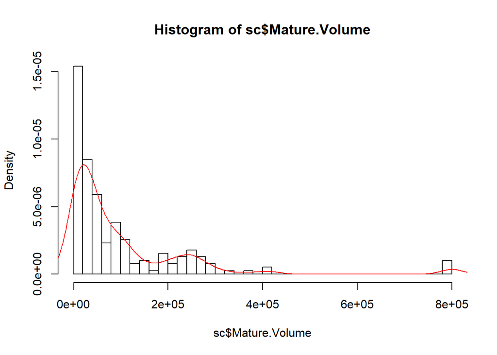

We have a few variables that are incoherent with the rest since thec are really far from the rest of the distribution without any valid reason regarding the other characteristics. We can assume there is an error here.

```r
sc <- sc %>% filter(Mature.Volume < 600000)
```

The others categories of the elements removed are quite normal (between the first and the third quarter), hence the idea of an error. By computing the others distribution, we do not notice any other outlier.

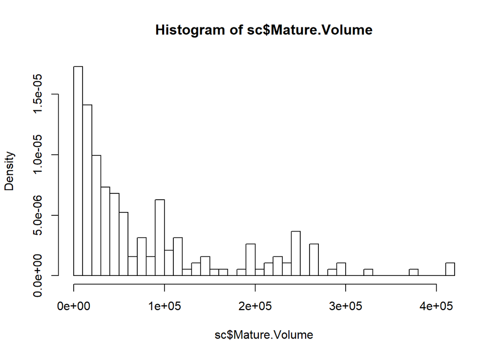

### First exploration

Let’s analyse the variables. Let’s have a look at the price distribution first.

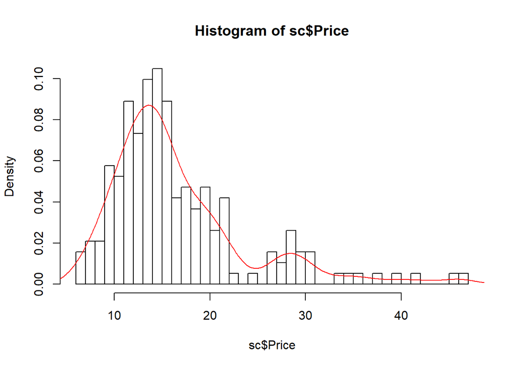

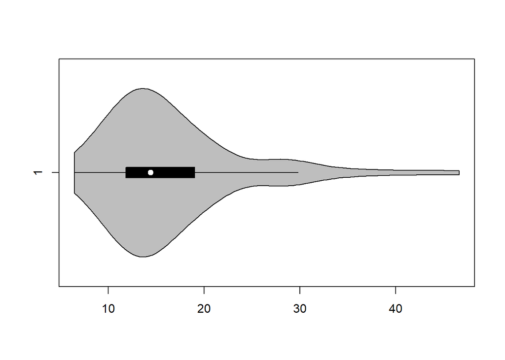

```r
quantile(sc$Price)
```

```
##        0%       25%       50%       75%      100%
##  6.477451 11.863612 14.431594 19.039530 46.610372
```

The distribution looks a bit like the sum of two normal distribution. One of them is much higher than the other one; we can distinguish ‘low cost’ screw caps from the ‘luxury’ ones. Most of them are ‘low cost’ though: 75% are between 6.5$ and 19$, which is the fork for the low budget caps.

Does the Price depend on the Length? On the weight?

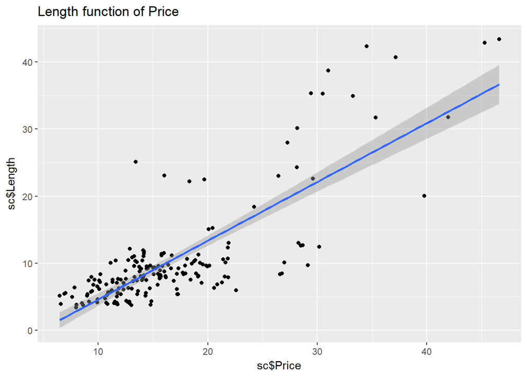

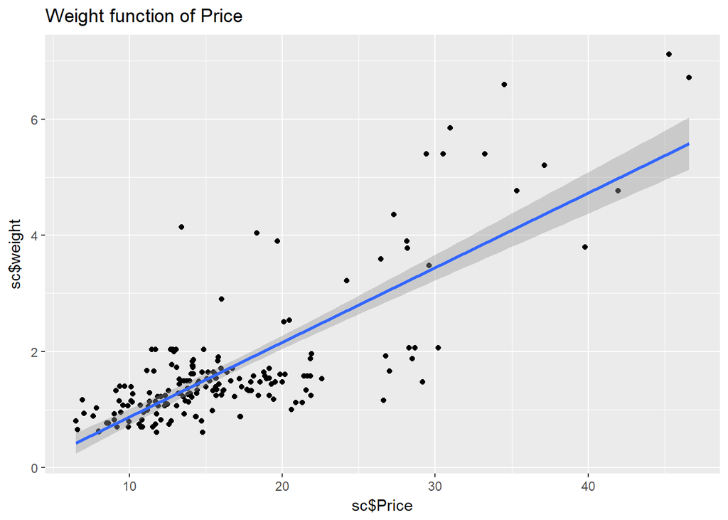

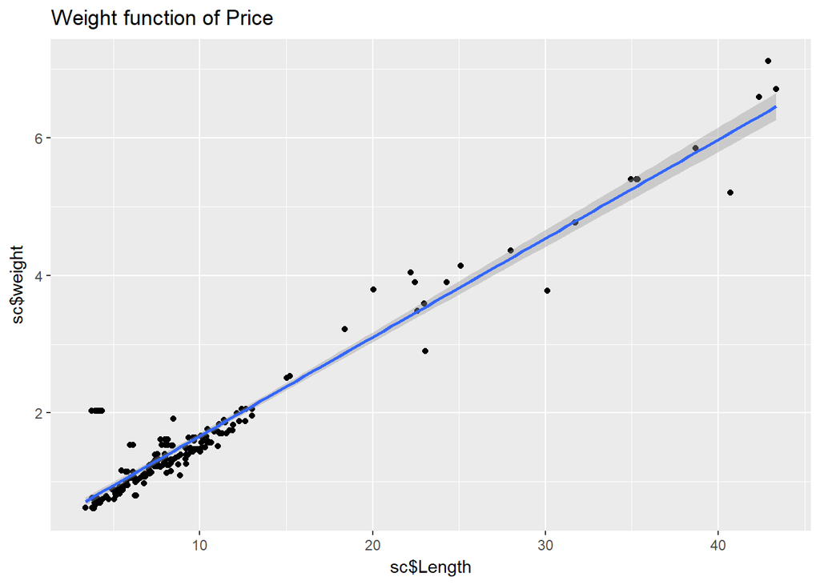

We can see that a global trend can be noticed for this graphs, which must however be used with caution. Indeed, the variance around the regression line is not as small as it could be if there was a strong link between the two variables (Length/Price, Weight/Price). For example, comparing to the curve between Length and Weight (which is easily understandable), the variance is much smaller.

Does the Price depend on the Impermeability? On the Shape?

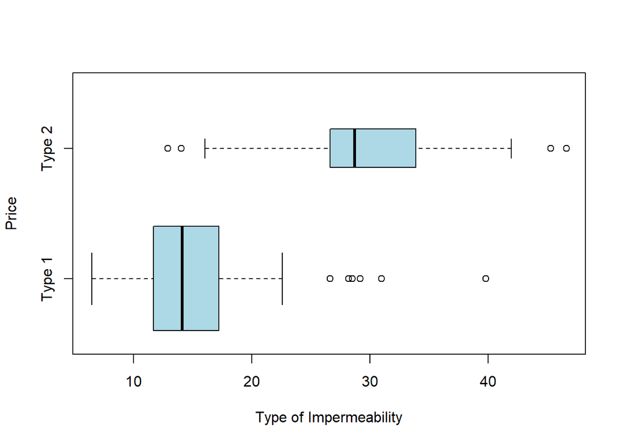

We can see with this plot that the impermeability has an influence on the price, since Type 2 is more explansive (more than 75% of type 2 has a price > 100% of Type 1). However, it is not a 100% determining criteria since they still intersect. A logistic regression could be very interesting here.

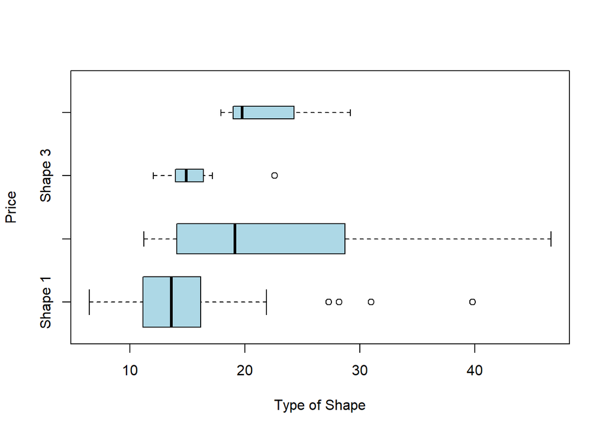

This graphs seems much more random than previously. We can see that Shape 3 is cheaper than Shape 4, and that globally Shape 1 is cheaper than Shape 2. However, all the shape taken into account, we can argue that the Shape does not really depends on the price since a clear hierarchy is not established with this graph.

Which is the less expensive Supplier?

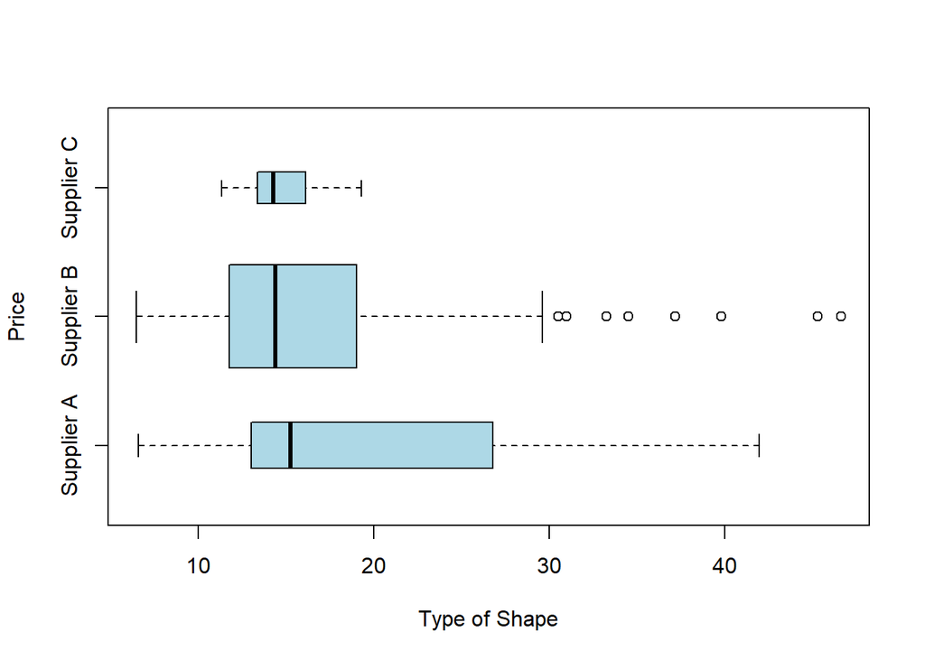

```r
Price_avg <- sc %>% select(Supplier,Price) %>% group_by(Supplier) %>% summarise(Average_Price = mean(Price))

Price_min <- sc %>% select(Supplier,Price) %>% group_by(Supplier) %>% summarise(Min_Price = min(Price))

boxplot(Price ~ Supplier, data = sc, xlab = "Type of Shape", ylab = "Price", varwidth = TRUE, col = "lightblue", horizontal=T)
```

```r
head(Price_avg)
```

```
## # A tibble: 3 x 2
##     Supplier Average_Price
##       <fctr>         <dbl>
## 1 Supplier A      18.52500
## 2 Supplier B      16.32317
## 3 Supplier C      14.88869
```

```r
head(Price_min)
```

```
## # A tibble: 3 x 2
##     Supplier Min_Price
##       <fctr>     <dbl>
## 1 Supplier A  6.598428
## 2 Supplier B  6.477451
## 3 Supplier C 11.329620
```

There are two answers for that question. the Supplier that offers the best price without looking at the other characteristics is the Supplier B (6.48$). However, in term of average, the supplier that has the lowest average, (14,89$), though this is not representative of the representation of the distribution).

### Principal Componant Analysis

By computing the PCA, we can read the inertia (which represents at which point each eigen value is important compared to the others), and analyse the projection thanks to the graphs plotted. In the “ideal” graph, all the variables are correlated to the two first, so are colinear to the axes of our circle, with a respectable length (loss of dimension), which means that the two variable chosen describe very well the dataset. The categories variables are displayed on the first graph, by computing the average of the coordinates of the observations that have the same category.

```r
pca <- PCA(sc, quali.sup = c(1, 5, 6, 7, 9), quanti.sup = 10)
```

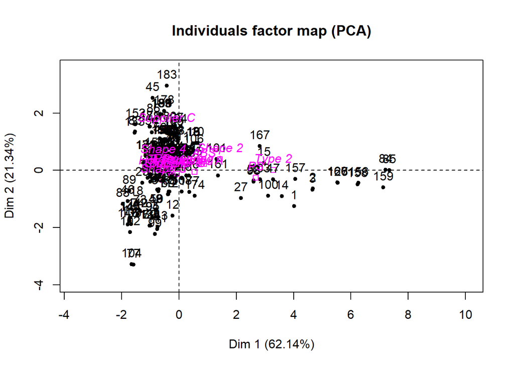

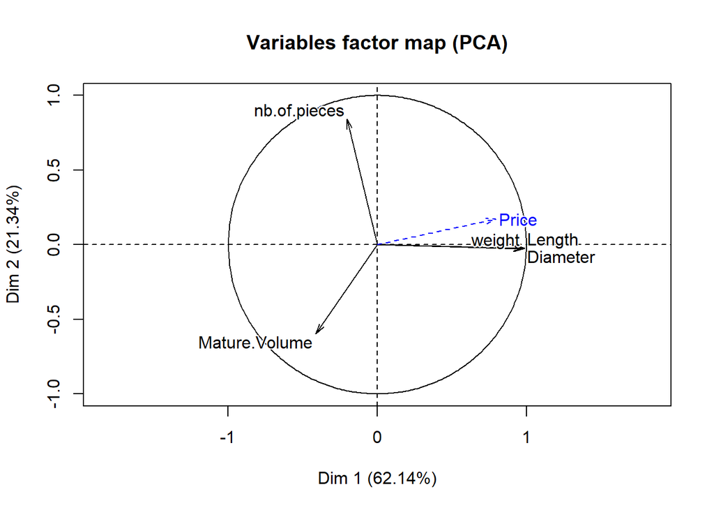

#### Study of the Correlation Matrix

```r
X <- as.matrix(sqrt((nrow(sc))/(nrow(sc)-1))*scale(as.matrix(sc %>% select(-c(1, 5, 6, 7, 9, 10)))))
V <- (t(X) %*% X) / nrow(X)
# cov offers a better precision
V <- cov(X)
V
```

```
##                 Diameter     weight nb.of.pieces Mature.Volume     Length
## Diameter       1.0052632  0.9673189  -0.14947761   -0.29318223  1.0049579
## weight         0.9673189  1.0052632  -0.16973232   -0.31486173  0.9678131
## nb.of.pieces  -0.1494776 -0.1697323   1.00526316   -0.07501739 -0.1471475
## Mature.Volume -0.2931822 -0.3148617  -0.07501739    1.00526316 -0.2951784
## Length         1.0049579  0.9678131  -0.14714745   -0.29517839  1.0052632
```

With this matrix we can confirm that Diameter, Lenght and Weight are higly correlated, and confirm the fact that it’s not the cas for the volume, which is not really correlated to the dimensions, and even more for the number of pieces. We can see the same on the correlation circle with the angles, where a right angle means independancy and colinear vectors are higly correlated.

#### Categorical Values:

PCA focuses on numeric values. That is a problem for this dataset where the price depends on them, especially the Impermability. We need to take them into account.

#### Analysis

**About the PCA:** We have a percentage of inertia that is around 84% for the two first eigen values, and more than 95% if we use the three first. This means that around 95% of the data is explained by the projection of the observations onto three normalized eigen vectors associated to the three biggest eigen values. We can also notice that Length, Weight, Diameters and Price are highly correlated (espacially the three characteristics of the dimensions of the caps), and very well explained by the first eigen vector. On the other hand, Mature volume and Number of pieces are betterly explained by the second eigen vector, and are not correlated to the Price (almost a right angle).

**About Type2 and PS:** Type 2 and PS are really close to each other, meaning that it is probable that they are linked (not 100% sure though; it’s just a mean). We can see that they are on the first axis, meaning that this first axis can explain these categories, whereas they not related to the second axis, since the mean of the coordinates of the observation that have these characteristics is approximatly zero.

### Coordinates of the two first dimensions

We need two eigen vectors of the two larger eigen values, to get the coordinates of the observation projected onto those two vectors.

```r
pca$var$coord[,1:2]
```

```
##                    Dim.1       Dim.2
## Diameter       0.9851090 -0.02547004
## weight         0.9774643 -0.02867601
## nb.of.pieces  -0.2017085  0.84267375
## Mature.Volume -0.4118157 -0.59567509
## Length         0.9853764 -0.02254298
```

### About the inertia

Thanks to the inertia, we can see that more than 95% of the data is explained by the projections on the three first eigen values. This means that projecting simplifies the dataset, removes maybe noise and get the calculation done faster thanks to the reduction of dimension.

### Clusterisation

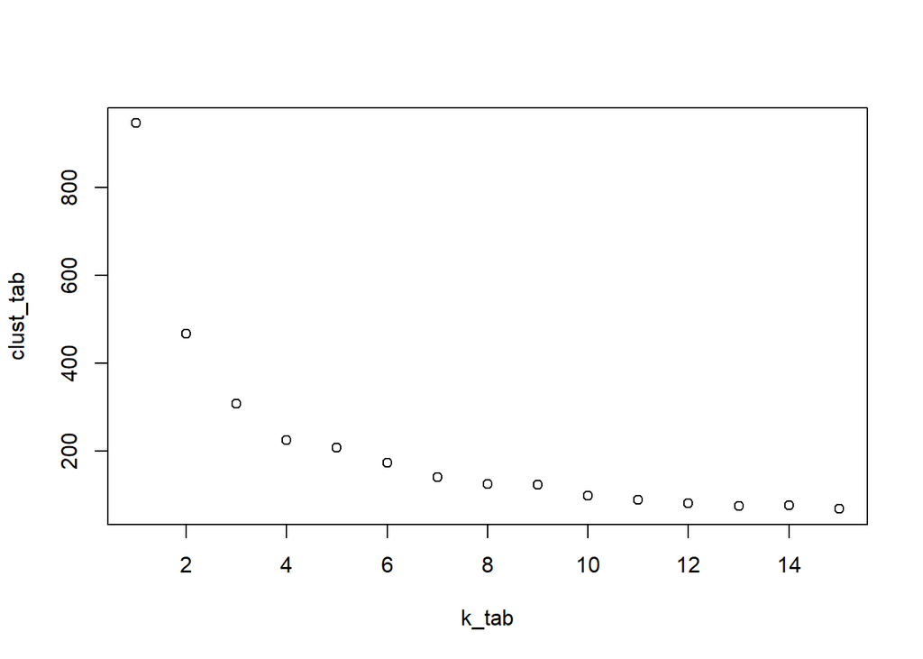

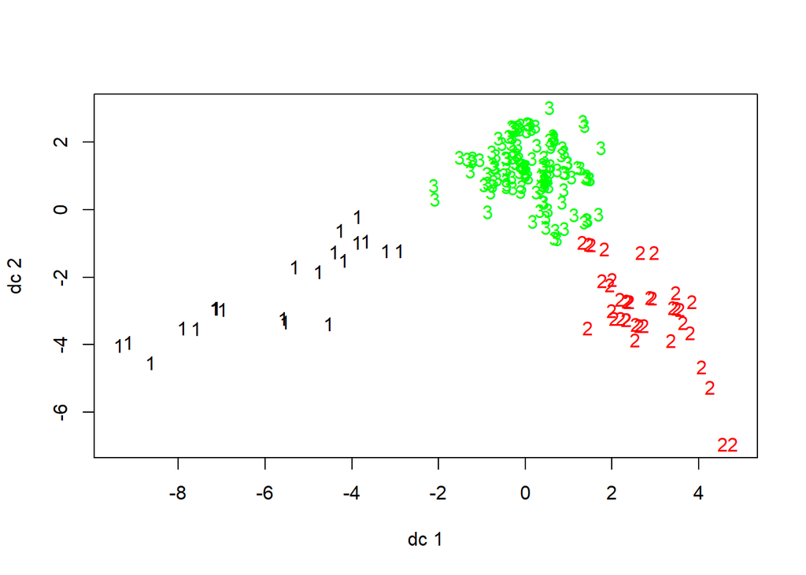

```r
clust <- kmeans(pca$ind$coord[,1:3], 3)

km <- function(i) return(kmeans(pca$ind$coord[,1:3], i)$tot.withinss)
clust_tab = c()
k_tab = 1:15
for(i in k_tab) clust_tab <- c(clust_tab, km(i))
```

To decide the number of cluster, we use the elbow method. We indeed chose the number of cluster that minimizes the cost function, without too many of them. We chose the number of cluster where there is not that much difference between n and n+1 but a step between n and n-1. Here in this example, we can chose n = 3.

```r
pca <- PCA(sc, quali.sup = c(1, 5, 6, 7, 9), quanti.sup = 10, ncp = 3)
```

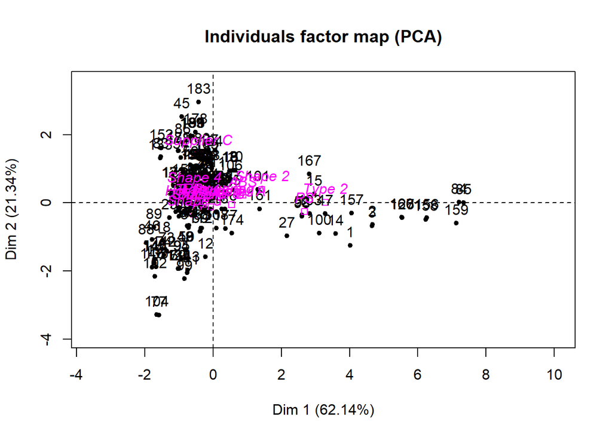

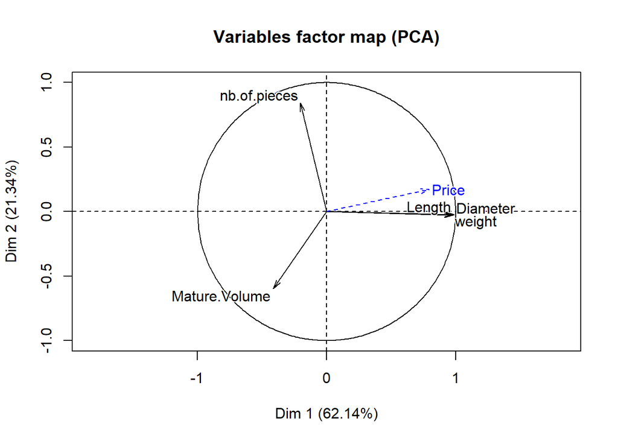

We use hcpc on the last pca, done with 3 dimensions.

```r
hcpc <- HCPC(pca, nb.clust = -1)
```

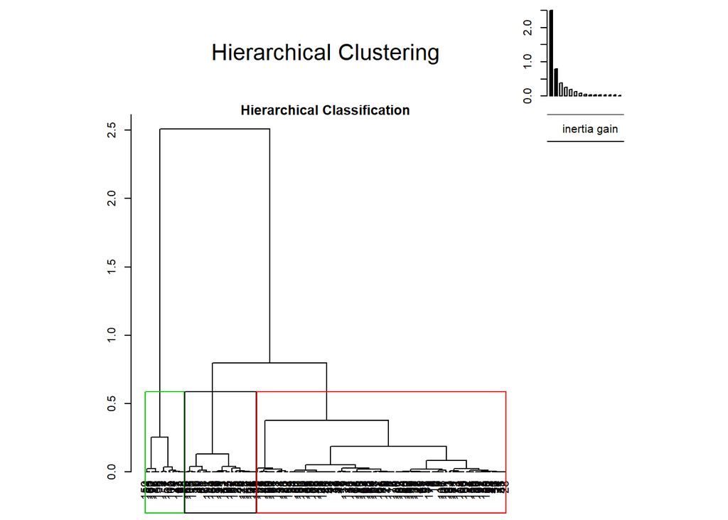

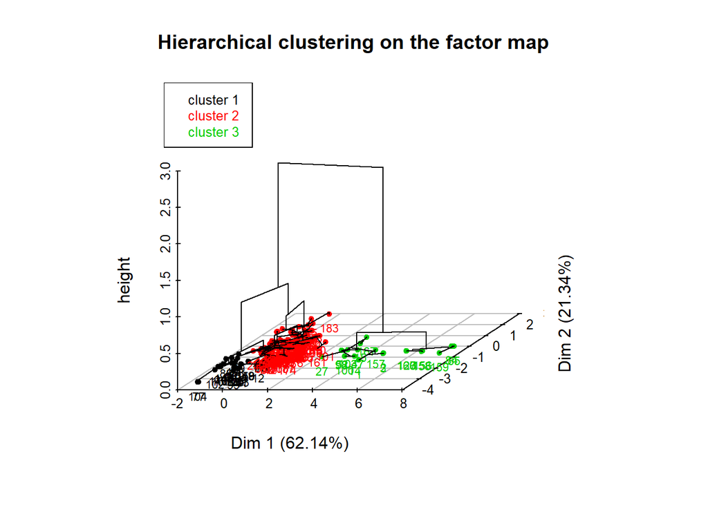

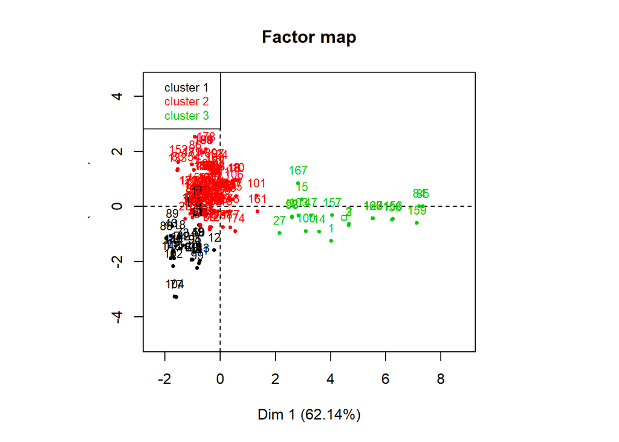

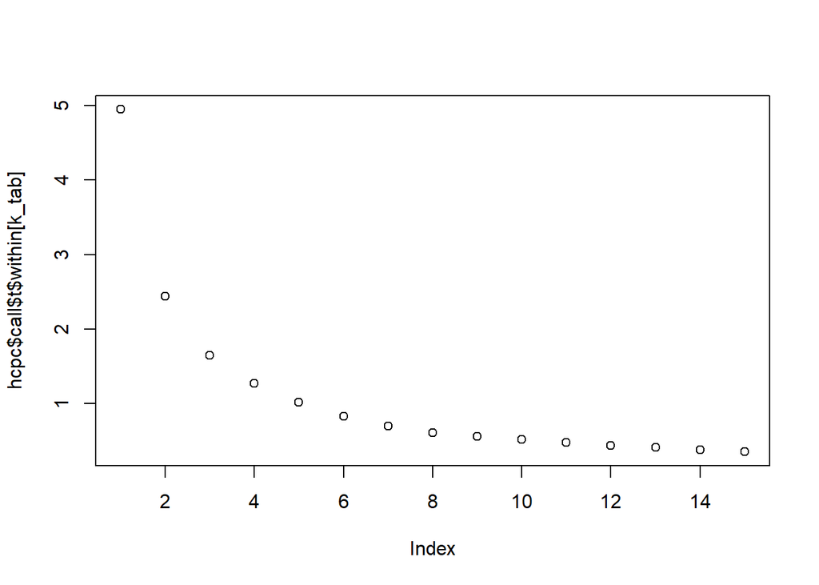

### Description of the clusters

We have the same number of cluster if we let the algorithm choose, and we can confirm this number by using the elbow method on the representation of the cost function.

We now want to describe a cluster. We need first to identify the variables that play a role in the clusterization. We display the result of the fisher test computed, for the continuous variables:

```r
hcpc$desc.var$quanti.var
```

```
##                    Eta2      P-value
## Length        0.8036361 3.530117e-67
## Diameter      0.8025769 5.853470e-67
## weight        0.8013378 1.053993e-66
## Mature.Volume 0.7588382 8.649758e-59
## Price         0.4812030 1.620918e-27
## nb.of.pieces  0.1760507 1.243497e-08
```

As we can see, all the p-values are low (<<0.05), and the dimensions explain better than the others variables (we remember the projection on the first axis in the PCA; this is not a suprise).

The same is done via a chi squared test for the qualitative variables:

```r
hcpc$desc.var$test.chi2
```

```
##                     p.value df
## Impermeability 5.318642e-18  2
## Raw.Material   5.226547e-17  4
## Shape          5.626207e-06  6
## Supplier       4.102258e-02  4
```

Here, the Finishing seems not to be a determining variable, whereas Impermeability and Raw.Material are the most decisive ones.

To describe one cluster in particular, the number 3 for example: For the quantitative variables:

```r
hcpc$desc.var$quanti$`3`
```

```
##                  v.test Mean in category Overall mean sd in category
## Length        12.298789        30.295407    10.329589   7.979008e+00
## Diameter      12.294570         3.787033     1.294639   1.000521e+00
## weight        12.254018         4.680731     1.714121   1.164251e+00
## Price          9.282815        30.295414    16.552332   8.814239e+00
## Mature.Volume -3.281665     20542.857143 82206.026178   1.547128e+04
## nb.of.pieces  -3.659694         3.047619     4.115183   7.221786e-01
##                 Overall sd      p.value
## Length        7.864783e+00 9.194180e-35
## Diameter      9.821218e-01 9.687099e-35
## weight        1.172854e+00 1.598746e-34
## Price         7.172431e+00 1.650583e-20
## Mature.Volume 9.103190e+04 1.031962e-03
## nb.of.pieces  1.413225e+00 2.525166e-04
```

We have here the mean and standard deviation of all the categories in the cluster number 3. We can see that the three dimensions (Length, Diameter and Weight) are more decisive to get into this cluster than the other variables.

For the categorical variables:

```r
hcpc$desc.var$category$`3`
```

```
##                          Cla/Mod   Mod/Cla   Global      p.value    v.test
## Impermeability=Type 2 65.2173913 71.428571 12.04188 2.909966e-12  6.982005
## Raw.Material=PS       57.6923077 71.428571 13.61257 4.169068e-11  6.597941
## Shape=Shape 2         31.1111111 66.666667 23.56021 9.932485e-06  4.418638
## Shape=Shape 1          5.3846154 33.333333 68.06283 6.715709e-04 -3.400930
## Impermeability=Type 1  3.5714286 28.571429 87.95812 2.909966e-12 -6.982005
## Raw.Material=PP        0.6944444  4.761905 75.39267 2.869539e-13 -7.300381
```

We can see here that Shape=Shape 2 is a relevant value to discriminate observation into the cluster 3 given the p-values.

```r
catdes(sc, num.var=1)
```

```
## $test.chi2
##                     p.value df
## Raw.Material   9.049049e-05  4
## Impermeability 1.088731e-02  2
##
## $category
## $category$`Supplier A`
##                        Cla/Mod  Mod/Cla   Global      p.value    v.test
## Raw.Material=PS       42.30769 37.93103 13.61257 0.0002998155  3.615459
## Impermeability=Type 2 34.78261 27.58621 12.04188 0.0130149176  2.483361
## Shape=Shape 2         26.66667 41.37931 23.56021 0.0213728107  2.301333
## Raw.Material=ABS       0.00000  0.00000 10.99476 0.0254288561 -2.234825
## Impermeability=Type 1 12.50000 72.41379 87.95812 0.0130149176 -2.483361
##
## $category$`Supplier B`
##                    Cla/Mod  Mod/Cla   Global     p.value    v.test
## Raw.Material=ABS 100.00000 14.18919 10.99476 0.003330616  2.935453
## Raw.Material=PS   57.69231 10.13514 13.61257 0.015928453 -2.410551
## Shape=Shape 2     60.00000 18.24324 23.56021 0.002374481 -3.038894
##
## $category$`Supplier C`
##                  Cla/Mod Mod/Cla   Global    p.value   v.test
## Raw.Material=PP 9.722222     100 75.39267 0.01626019 2.403023
##
##
## $quanti.var
##                   Eta2      P-value
## nb.of.pieces 0.2137072 1.530822e-10
##
## $quanti
## $quanti$`Supplier A`
## NULL
##
## $quanti$`Supplier B`
##                 v.test Mean in category Overall mean sd in category
## nb.of.pieces -2.817845         3.959459     4.115183       1.240523
##              Overall sd     p.value
## nb.of.pieces   1.413225 0.004834708
##
## $quanti$`Supplier C`
##                v.test Mean in category Overall mean sd in category
## nb.of.pieces 6.345875         6.428571     4.115183       1.720228
##              Overall sd      p.value
## nb.of.pieces   1.413225 2.211654e-10
##
##
## attr(,"class")
## [1] "catdes" "list "
```

One can notice that this function prints out the characteristics of clusters following a catagery, here Supplier A, B or C. We can then try to describe the main features of a supplier, which is extremely useful for a company, to understand each supplier’s strength, line of business and differentiate them. In this example, we can see that Raw Materials plays an important role in the distinction between suppliers, with A using mostly PS, B : ABS and C : PP.

### About the eigen values

```r
pca$eig
```

```
##          eigenvalue percentage of variance
## comp 1 3.1071215080           62.142430160
## comp 2 1.0669070766           21.338141532
## comp 3 0.7768681861           15.537363723
## comp 4 0.0488056018            0.976112036
## comp 5 0.0002976274            0.005952549
##        cumulative percentage of variance
## comp 1                          62.14243
## comp 2                          83.48057
## comp 3                          99.01794
## comp 4                          99.99405
## comp 5                         100.00000
```

The choice of the number of the components kept is explained with an elbow method on the percentage of importance of the eigen values. With 99.02%, we keep most of the data, and adding the 4th and 5th components won’t change much, as we can see if we clusterize using 5 components.

### Taking Categorical Values into account, FAMD

```r
famd = FAMD(sc, ncp = 10, sup.var = c(10))
```

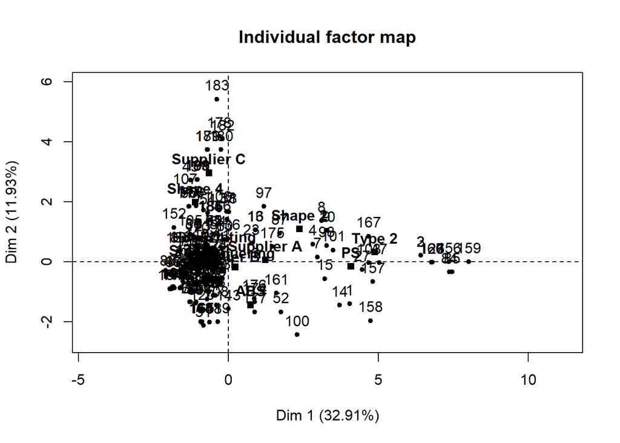

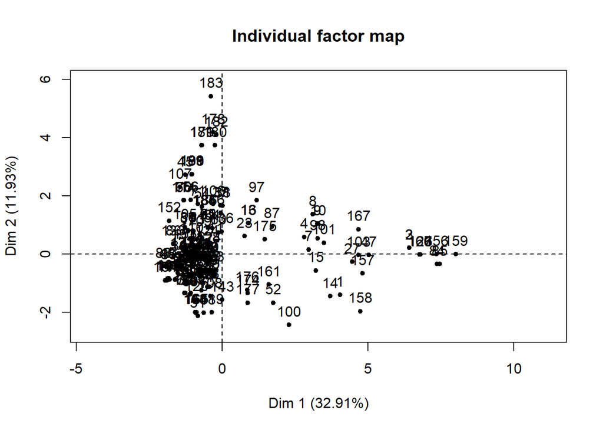

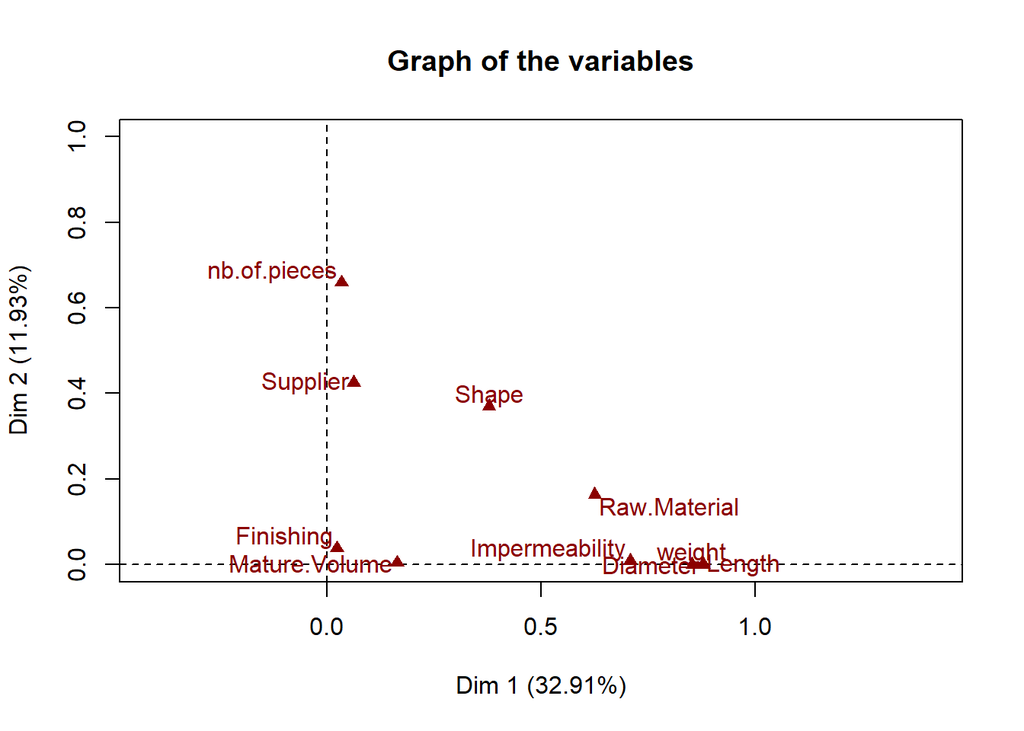

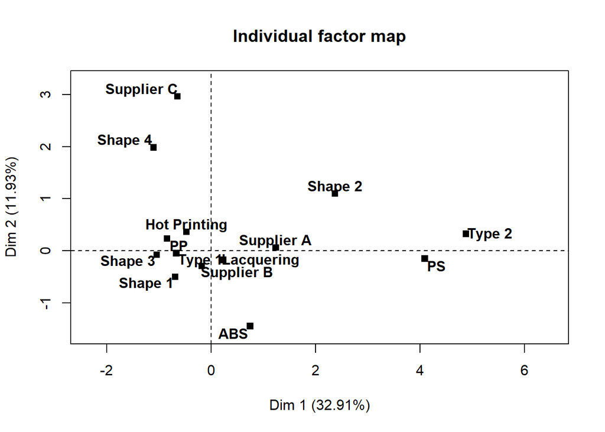

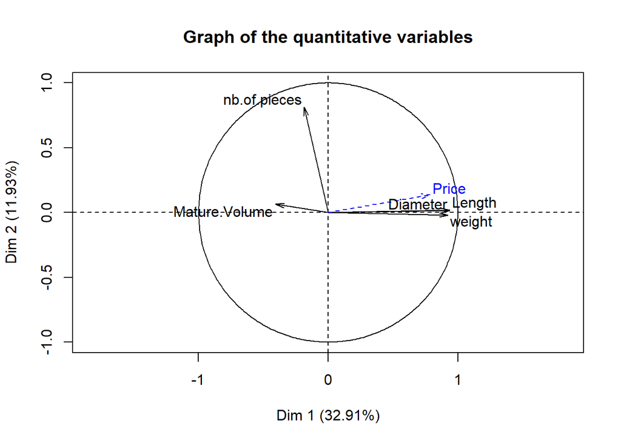

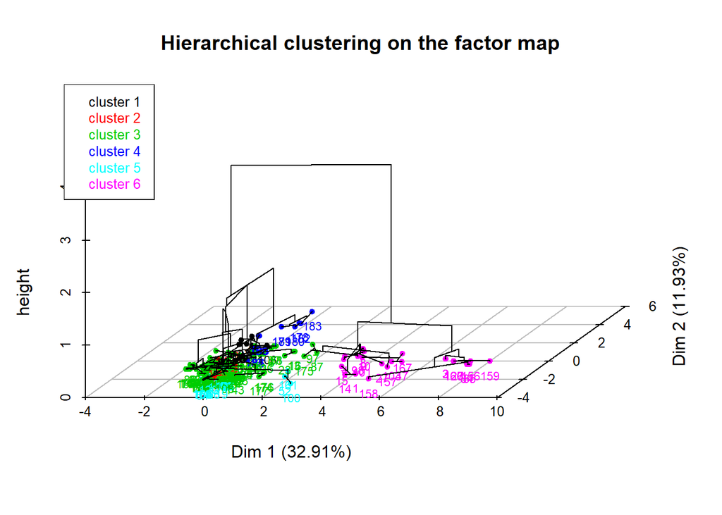

```r
hcpc <- HCPC(famd, nb.clust = -1, graph =  FALSE)
plot.HCPC(hcpc)
```

FAMD takes into account more paramaters, which means more data that are not necessarly correlated to the previous ones, meaning we need more dimension to represent with enough accuracy the data. To reach 95% for the cumulative percentage of variance, we need 10 dimensions. With these new graphs, we can assume that the price is related to Impermeability and partially to Raw Material, and not with the Supplier: using the rgaph of the variables, we can see that the former depend mostly of axis 1 and the later axis 2. Shape is in between.

### Regression and tests

We need for the regression to be able to test it, by training the coefficient on a part of the dataset and testing it on the other part.

```r
iTest <- sample(x=1:nrow(sc), size=floor(0.2*nrow(sc)))
scTest <- sc[iTest,]
scTraining <- sc[-iTest,]


fit <- lm(Price ~ Diameter + Length + weight, data=scTraining)
summary(fit)
```

```
##
## Call:
## lm(formula = Price ~ Diameter + Length + weight, data = scTraining)
##
## Residuals:
##     Min      1Q  Median      3Q     Max
## -14.193  -2.539  -0.729   2.365  15.167
##
## Coefficients:
##             Estimate Std. Error t value Pr(>|t|)
## (Intercept)   8.8070     0.6575  13.394   <2e-16 ***
## Diameter      9.9899    14.4490   0.691    0.490
## Length       -0.7477     1.8148  -0.412    0.681
## weight        1.5572     1.0659   1.461    0.146
## ---
## Signif. codes:  0 '***' 0.001 '**' 0.01 '*' 0.05 '.' 0.1 ' ' 1
##
## Residual standard error: 4.38 on 149 degrees of freedom
## Multiple R-squared:  0.6137, Adjusted R-squared:  0.6059
## F-statistic:  78.9 on 3 and 149 DF,  p-value: < 2.2e-16
```

```r
pred <- predict.lm(fit,scTest)
real <- scTest$Price
recap <-  data_frame(pred,real)
recap$diff <- abs(pred-real)
quantile(recap$diff)
```

```
##          0%         25%         50%         75%        100%
##  0.04832925  1.35674562  2.51363495  4.15235501 13.11758670
```

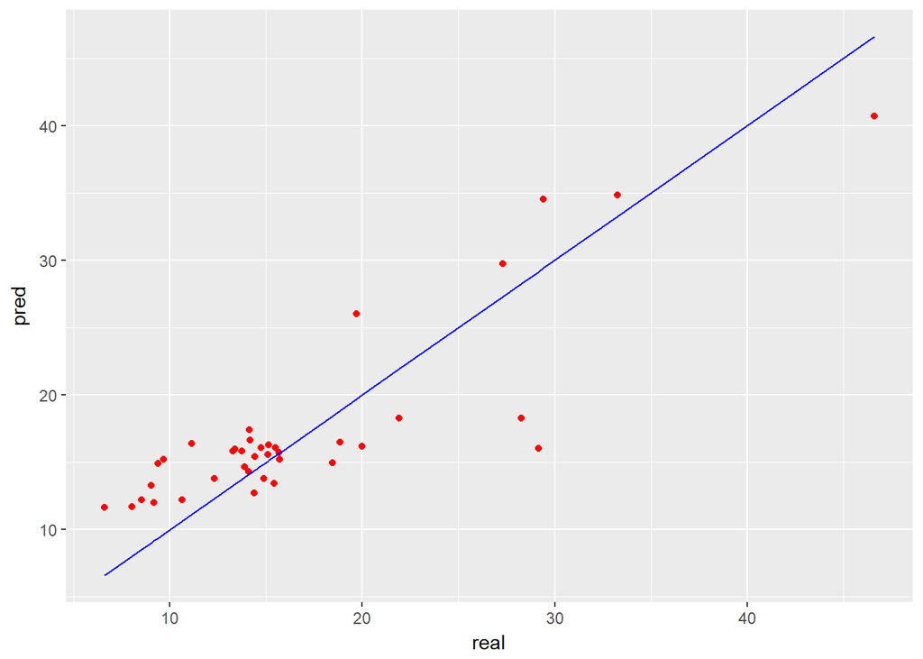

We can see that the model is not perfect, but we can predict with an error of around 3$ 50% of the data and 4$ for 75%. The previous analysis allow us to explain to the most far away points, because of the irrelevance of certain categories.

The supplier does not havec an influence on the price (using the PCA), so treating them seperatly do not bring anything.

### About the missing values

One could suggest adding a predefined value to all the missing values. However, adding 0 or the median is not a good idea since it changes the relation between the variables, and falsifies the variance of the variable. A better idea would be to use a stochastic approach, by using randomness. The idea of adding a new category “missing” is dangerous. Indeed, the fact that the data is missing has nothing to do with the price itself; however, adding a new category would be taken into account as a possible explaination for the price.